# Power analysis in Developmental Psychology

25/07/2019

## Some context…

## Statistical inference

The goal of every statistical inference is to:

- Make the decission most **supported by data**
- Accurately represent our **uncertainty** on such decission

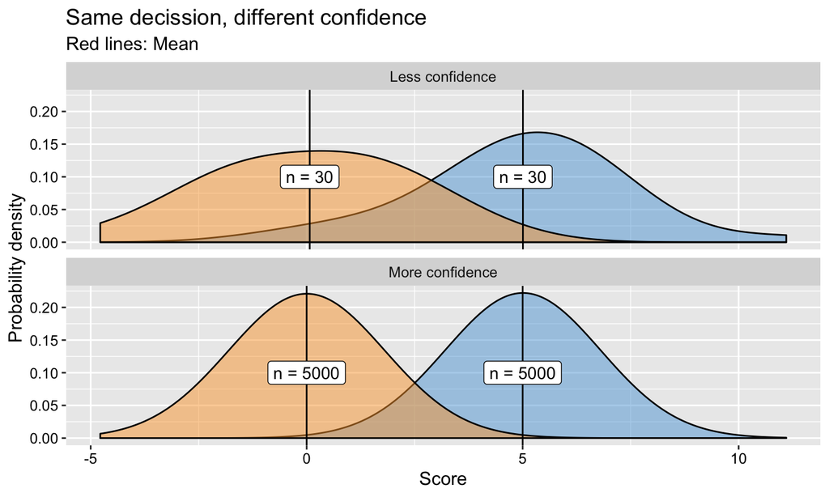

## NHST

### One path toward statistical inference

**Null Hypothesis Significance Testing (NHST)**

Specify a null hypothesis (\(H_0\)) and an alternative hypothesis (\(H_1\)).

Test the \(H_0\) and decide whether to reject it or not:

1. Asume \(H_0\) is true.
2. Calculate a statistical value:
   1. That reflects the parameter we are interested in (e.g. *t*-value for differences in means or *F*-value for variance explained by factor)
   2. For which we know its probabilistic distribution at the population level (e.g. Student’s *t* or Snedecor’s *F*)
3. If the probability associated to our statistic (according to the distribution) is lower than our significance criterion (\(\alpha\)), we reject the \(H_0\): our data is very unlikely to have been generated under such scenario.

## Null Hypothesis Significance Testing

Specify a null hypothesis (\(H_0\)) and an alternative hypothesis (\(H_1\)).

Test the \(H_0\) and decide whether to reject it or not:

1. Asume the **null hypothesis** is true.
2. Calculate a statistical value:
   1. That reflects the parameter we are interested in (e.g. *t*-value for differences in means or *F*-value for variance explained by factor)
   2. For which we know its probabilistic distribution at the population level (e.g. Student’s *t* or Snedecor’s *F*)
3. If the probability (*p*) associated to our statistic (according to the distribution) is lower than our **significance** criterion (\(\alpha\)), we reject the null hypothesis: our data is very unlikely to have been generated under such scenario.

## *p*-values

*p*-values in the context of NHST indicate the probability of our data (i.e. statistic of contrast) under the null hypothesis.

We compare the *p*-value we have against our significance criterion.

Significance criterion (\(\alpha\)): how unlikely must our data be to be considered too unlikely to have been generated under the null hypothesis.

If *p*-value < \(\alpha\) \(\to\) Reject \(H_0\)

## *p*-values

Let’s take a look at Daniel Laken’s shiny app for exploring how *p*-values behave under some conditions: [[link]](https://lakens.shinyapps.io/p-curves/).

- Under \(H_0\), all *p*-values are equally likely.
- Under \(H_1\), lower *p*-values are more likely.

## Two types of incorrect decisions

Statistical inference is **probabilistic**. We cannot know if our decission to reject (or not to reject) the null hypothesis is correct. If we knew it, statistical inference would be unnecessary.

## Controlling our error rates

### Type I error rate

Specify the cost of each error, and adjust the rest of parameters to them.

Assume there is **no effect**. The probability of (incorrectly) rejecting \(H_0\) is \(\alpha\).

If we set \(\alpha\) very low, only very unlikely *p*-values will lead to the rejection of \(H_0\) If we set \(\alpha\) very high, we could reject \(H_0\) when *p*-values are quite high.

Usually false positives are considered more **costly**, so we usually fix \(\alpha\) at a very low level (e.g. 0.05), and adjust the rest of parameters.

## Controlling our error rates

### Type I error rate

I need to get an NBA player. How can I select one person to make my best guess?

[Article](https://www.si.com/vault/2015/07/05/106084744/larger-than-real-life) by Pablo S. Torre for *Sports Illustrated*: there is a .17 probability that, if you are a 7 feet high American man, you are an NBA player.

## Controlling our error rates

### Type II error rate

Assume there **is** an effect. The probability of (incorrectly) not rejecting \(H_0\) is \(\beta\).

Given \(\alpha\), we will try to minimise \(\beta\) (i.e. to maximise 1-\(\beta\), statistical power), as much as possible.

What does statistical power depend on?

- Significance criterion (\(\alpha\)): fixed *a priori*
- **Effect size of interest**: defined by experimenter based on theoretical or empirical literature.
- Type of analysis: defined by experimenter.

Lets guess our power!

## Controlling our error rates

### Type II error rate

Assume there **is** an effect. The probability of (incorrectly) not rejecting \(H_0\) is \(\beta\).

Given \(\alpha\), we will try to minimise \(\beta\) (i.e. to maximise 1-\(\beta\), statistical power), as much as possible.

What does statistical power depend on?

- Significance criterion (\(\alpha\)): fixed *a priori*
- **Effect size of interest** (ES): defined by experimenter based on theoretical or empirical literature.
- Type of analysis: defined by experimenter.
- **Sample size** (N)

Lets guess our power!

## Our data

**Visual word paradigm** task

Two objects are presented, one of them is named.

How long do **monolinguals** vs. **bilinguals** look to the correct (target) object?

Independent *t*-test comparing monolinguals’ and bilinguals’ looking time to target.

## Power analysis

### *A priori*

Given \(\alpha\), *ES*, and having decided our analysis, what *N* do we need to achieve given desired power?

We know…

- Significance criterion (\(\alpha\)): 0.05.
- Desired stat. power (1-\(\beta\)): 0.80.
- Analysis: independent two-samples *t*-test

We don’t know…

- Effect size (*ES*): How big is my effect size of interest? NOT THE ONE I FOUND ONCE I HAVE PERFORMED THE ANALYSIS! Our best guess is a Cohen’s *d* of 0.6.

We want to calculate:

- Sample size (*N*)

## Power analysis

### *A priori*

```r
pwr::pwr.t.test(
  sig.level = 0.05,          # significance criterion (alpha)
  d = 0.6,                   # effect size of interest (ES)
  type = "two.sample",       # two independent samples
  alternative = "two.sided", # both BL>ML and ML>BL can lead to rejection of H0
  power = 0.80               # desired statistical power
)
```

```
##
##      Two-sample t test power calculation
##
##               n = 44.58577
##               d = 0.6
##       sig.level = 0.05
##           power = 0.8
##     alternative = two.sided
##
## NOTE: n is number in *each* group
```

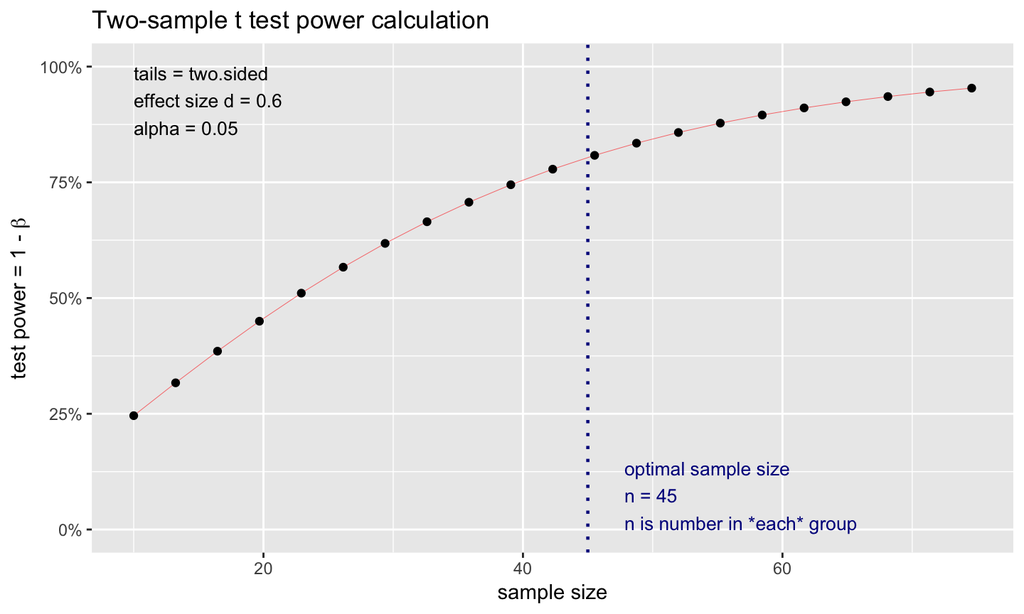

```r
pwr::pwr.t.test(
  sig.level = 0.05,          # significance criterion (alpha)
  d = 0.6,                   # effect size of interest (ES)
  type = "two.sample",       # two independent samples
  alternative = "two.sided", # both BL>ML and ML>BL can lead to rejection of H0
  power = 0.80               # desired statistical power
) %>%
  pwr::plot.power.htest(.) # show power curve
```

## Power analysis

### *A posteriori*

Our data:

| Participant | Group | Looking time (ms) |
| --- | --- | --- |
| id1 | Monolinguals | 429.21 |
| id2 | Monolinguals | 289.02 |
| id3 | Monolinguals | 695.56 |
| id4 | Monolinguals | 843.65 |
| id5 | Monolinguals | 1187.69 |
| id6 | Monolinguals | 917.74 |
| id75 | Bilinguals | 1395.68 |
| id76 | Bilinguals | 1696.94 |
| id77 | Bilinguals | 1187.27 |
| id78 | Bilinguals | 1143.10 |
| id79 | Bilinguals | 1341.08 |
| id80 | Bilinguals | 980.69 |

[output not shown]

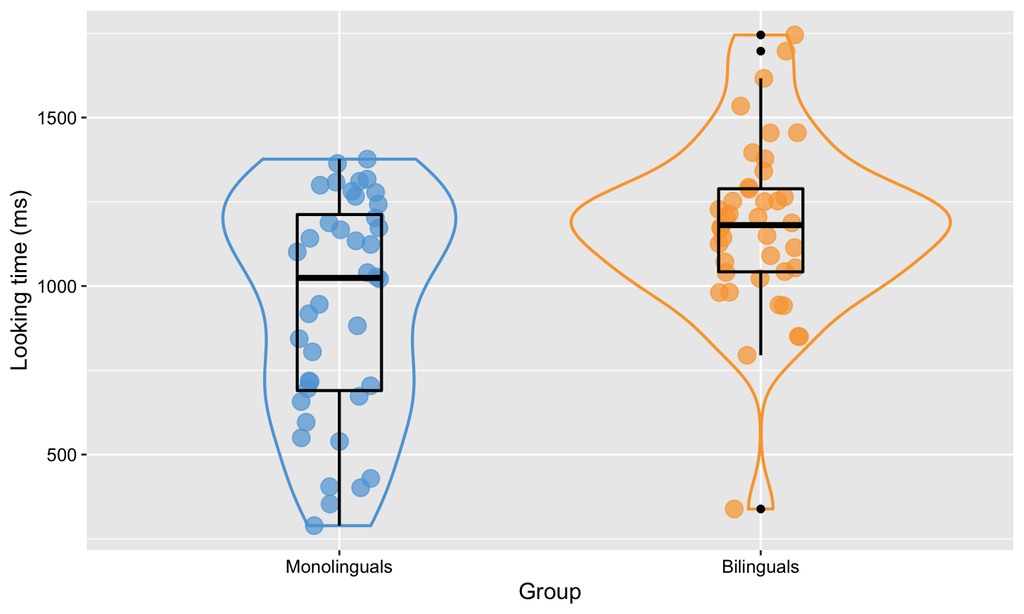

**Significance testing**:

```r
t.test(
  formula = looking_time ~ group, # specify response variable and predictors
  data = data                     # specify table with data
)
```

```
##
##  Welch Two Sample t-test
##
## data:  looking_time by group
## t = -3.6647, df = 73.946, p-value = 0.0004631
## alternative hypothesis: true difference in means is not equal to 0
## 95 percent confidence interval:
##  -372.5297 -110.1108
## sample estimates:
## mean in group Monolinguals   mean in group Bilinguals
##                   937.0058                  1178.3261
```

```r
t.test <- t.test(
  formula = looking_time ~ group, # specify response variable and predictors
  data = data                     # specify table with data
)
es <- t.test$statistic/sqrt(40)

es
```

```
##          t
## -0.5794446
```

We reject the null hypothesis of equal looking times in monolinguals and bilinguals.

**What is the power of this test?**

- We can’t get more participants
- We still want to keep a decent power!

*What is the lowest effect size our test would be able to detect?*

```r
abs(qt(p = 0.05/2, df = (40-2)))
```

```
## [1] 2.024394
```

Get critical Cohen’s *d*: `d_critical = t_critical/sqrt(n)`

```r
abs(qt(p = 0.05/2, df = (40-2)))/sqrt(40)
```

```
## [1] 0.3200848
```

## Simulation-based power analysis

## Same experiment over 1000 repetitions

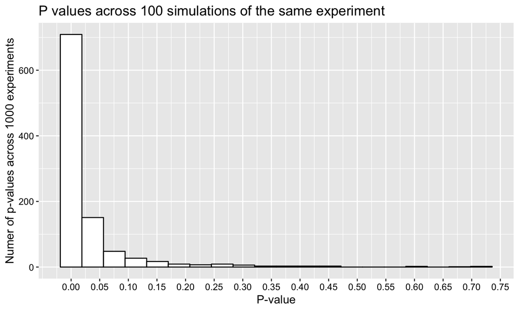

## When the effect is small

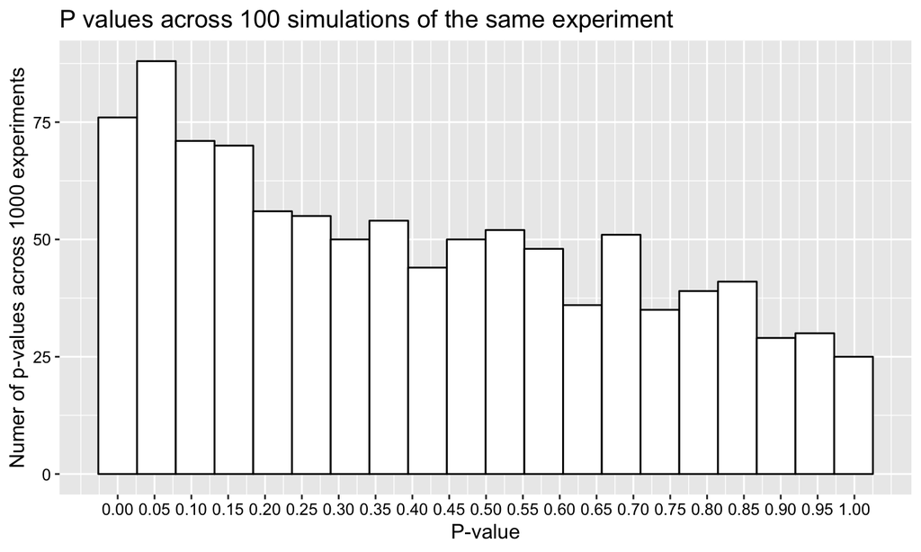

## When there is no effect

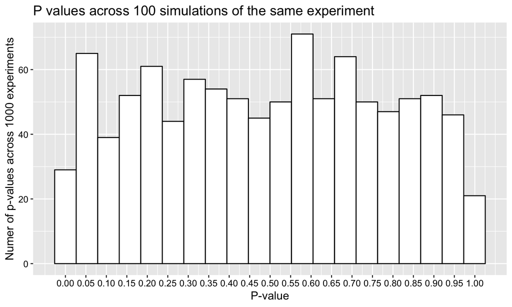